Seminario Doctoral · Ciencias Sociales Computacionales

# Campo disciplinar y epistemológico de las **Ciencias Sociales Computacionales**

- La consolidación, desde los años 2000, de un área de investigación entre las ciencias sociales y las ciencias de la computación.

Sesión1

MódulosFundamentos · Lecturas

ProfesorRoberto Velázquez-Quiroz

Computer Science

Social Epistemology

Data Science

Methodology

Social Science

Design

Hoja de ruta

## ¿Qué tipo de ciencia es la CSS?

Módulo 1 · Exposición

### Fundamentos de las Ciencias Sociales Computacionales

1. Ciencias Sociales Computacionales (CSS)Genealogías, definiciones y alcance del campo
2. El papel de la teoría en la era del *big data*Describir, explicar, predecir · viejos enigmas, nueva evidencia
3. Datos en la era del *big data*Datos encontrados vs. diseñados · diez características · acceso
4. La cuestión ética en el diseño entre sesgos algorítmicosPrivacidad, principios y profecías autocumplidas

Módulo 2 · Discusión sobre lecturas

### Del manifiesto a la práctica de investigación

1. Áreas de investigaciónEl mapa de subcampos de Edelmann et al. (2020)
2. El papel de la programación en la investigación socialInstrumento y paradigma (Cioffi-Revilla, 2022)
3. Potencial analíticoQué preguntas se vuelven posibles y cuáles siguen fuera de alcance

Seminario Doctoral · Ciencias Sociales ComputacionalesSesión 1

Lecturas obligatorias

## Cinco textos, cinco posiciones sobre el campo

|  | Texto | Pregunta de discusión |
| --- | --- | --- |
| 01 | **Lazer, D., et al. (2009).** Computational Social Science. *Science*, 323(5915), 721–723. Manifiesto fundacional | ¿Qué promete una ciencia social basada en trazas digitales y qué obstáculos anticipa? |
| 02 | **Lazer, D. M. J., et al. (2020).** Computational Social Science: Obstacles and Opportunities. *Science*, 369(6507), 1060–1062. Balance a once años | ¿Por qué el campo creció, pero sus instituciones (datos, ética, universidad) quedaron atrás? |
| 03 | **González-Bailón, S. (2017).** *Decoding the Social World*, cap. 2: Old Puzzles, New Evidence. MIT Press. Teoría social clásica | ¿Cómo ayudan los datos digitales a resolver enigmas de Merton, Schelling y la mano invisible? |
| 04 | **Edelmann, A., Wolff, T., Montagne, D. & Bail, C. A. (2020).** Computational Social Science and Sociology. *Annual Review of Sociology*, 46, 61–81. Mapa disciplinar | ¿Dónde ha penetrado la CSS en la sociología y qué le exige a la teoría sociológica? |
| 05 | **Cioffi-Revilla, C. (2022).** The Scope of Computational Social Science. En *Handbook of Computational Social Science*, Vol. I. Routledge. Contrapunto | ¿Es la CSS una ciencia del *big data* o una ciencia de teorías, modelos y simulaciones? |

Seminario Doctoral · Ciencias Sociales ComputacionalesSesión 1

01

## Fundamentos de las Ciencias Sociales Computacionales

Qué es el campo, cómo se relaciona con la teoría, qué tipo de datos lo sostienen y qué dilemas éticos plantea su diseño.

1.1 · CSS1.2 · Teoría1.3 · Datos1.4 · Ética y sesgos

Seminario Doctoral · Ciencias Sociales ComputacionalesMódulo 1

1.1

## Ciencias Sociales Computacionales

Seminario Doctoral · Ciencias Sociales ComputacionalesMódulo 1 · CSS

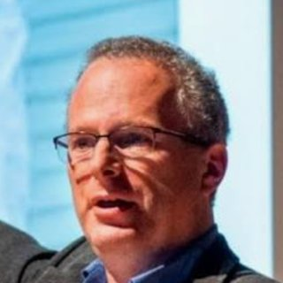

1.1 · Ciencias Sociales Computacionales

> “Vivimos la vida en la red. [...] Cada una de estas transacciones deja trazas digitales que pueden compilarse en imágenes exhaustivas del comportamiento individual y grupal.”

Lazer et al. (2009, p. 721), *Science*. Traducción propia.

El manifiesto de 2009, firmado por quince autores de la física, la informática, la sociología, la ciencia política y la economía, advierte que esta ciencia ya existía, pero **en Google, Yahoo y la NSA**. El riesgo: que quede en manos privadas o de una élite académica que produzca resultados que no pueden criticarse ni replicarse.

Seminario Doctoral · Ciencias Sociales ComputacionalesMódulo 1 · CSS

1.1 · Ciencias Sociales Computacionales

## Una consolidación con raíces largas

El rótulo se populariza tras 2009, pero la computación entra a la ciencia social en los años sesenta. Cioffi-Revilla insiste en que el campo no nace con el *big data*; Edelmann et al. muestran que la producción explota después de 2012.

[figure not shown]

Fuentes: Cioffi-Revilla (2022, p. 21); González-Bailón (2017, cap. 2); Edelmann et al. (2020, pp. 62–64); Keuschnigg et al. (2018); Bail (2024).

Seminario Doctoral · Ciencias Sociales ComputacionalesMódulo 1 · CSS

1.1 · Ciencias Sociales Computacionales · Fuentes históricas

## Obras fundamentales

[figure not shown]

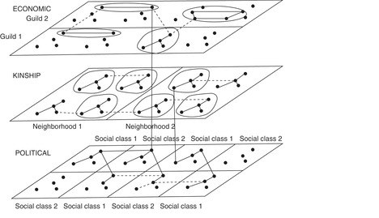

**Harrison C. White (1992; 2ª ed. 2008). *Identity and Control*. Princeton UP.** Los actores están inscritos a la vez en varias redes (económica, de parentesco, política). Los vínculos que cruzan capas generan la estructura social: la posición de un actor depende de cómo se superponen sus redes.

Ejemplo: modelo de bloques estocástico multicapa $P(Aij[k]=1∣zi,zj)=πzizj[k],k∈{eco,par,pol}$ El rol *z<sub>i</sub>* de cada actor es común a todas las capas; la probabilidad de vínculo *π* cambia según la capa *k*.

[figure not shown]

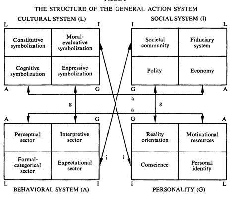

**Talcott Parsons (1951). *The Social System*. Free Press.** El sistema general de acción tiene cuatro subsistemas funcionales (AGIL): organismo conductual (A, adaptación), personalidad (G, logro de metas), sistema social (I, integración) y cultura (L, latencia). Se regulan mediante intercambios de información y energía.

Ejemplo: modelo de ecuaciones estructurales $η=Bη+Γξ+ζ,η=(ηA,ηG,ηI,ηL)⊤;y=Λη+ε$ Cada subsistema es un factor latente medido por indicadores **y**; la matriz **B** representa los intercambios entre subsistemas.

Las ecuaciones son formalizaciones ilustrativas para la discusión, no aparecen en las obras originales.

Seminario Doctoral · Ciencias Sociales ComputacionalesMódulo 1 · CSS

1.1 · Ciencias Sociales Computacionales

## Cuatro definiciones, cuatro énfasis

### Lazer et al. (2009, p. 722)

> “Una ciencia social computacional emerge que aprovecha la capacidad de **recolectar y analizar datos** con una **amplitud, profundidad y escala sin precedentes**.”

Énfasis: **la escala de los datos**

### Lazer et al. (2020, p. 1060)

> “El desarrollo y la aplicación de **métodos computacionales** a **datos complejos**, típicamente a gran escala, sobre **comportamiento humano** (a veces simulado).”

Énfasis: **los métodos**

### Edelmann et al. (2020, p. 62)

> “Un **campo interdisciplinario** que **hace avanzar teorías del comportamiento humano** aplicando **técnicas computacionales** a grandes bases de datos de redes sociales, internet u otros archivos digitalizados.”

Énfasis: **la teoría sociológica**

### Cioffi-Revilla (2022, pp. 17–18)

> Un campo **guiado por la teoría**, **enriquecido por modelos analíticos** y **habilitado por simulaciones computacionales**, “todo ello a partir de **datos, sean grandes o pequeños**”.

Énfasis: **el paradigma computacional**

Traducciones propias. Edelmann et al. advierten que su definición, centrada en la explicación, “no es un consenso” fuera de la sociología.

Seminario Doctoral · Ciencias Sociales ComputacionalesMódulo 1 · CSS

1.1 · Ciencias Sociales Computacionales

## Dos genealogías que conviven en el mismo rótulo

Desde las ciencias sociales

### Simulación y teoría

En la ciencia social, el término describió primero los **modelos basados en agentes**: programas que simulan conducta humana en poblaciones artificiales (Edelmann et al., 2020, p. 62).

Cioffi-Revilla lo remonta a los años sesenta y al paradigma de **sistemas complejos adaptativos** de Herbert Simon: la computación como teoría del procesamiento de información a toda escala social.

Produjo avances teóricos en psicología social y redes (Macy y Willer, 2002; Centola y Macy, 2007).

vs.

Desde la física y la informática

### Datos masivos y patrones

En los campos STEM, cualquier estudio con **grandes bases sobre conducta humana** se llama CSS: teorías elegantes de la física aplicadas a dinámicas colectivas, pero “en gran medida desconectadas de la teoría social” (Edelmann et al., 2020, p. 62).

Keuschnigg et al. (2018) señalan que estos investigadores suelen buscar **“leyes sociales”**, mientras la sociología analítica busca **mecanismos**.

Cioffi-Revilla (2022, nota 1) llama a esta versión “Big Data CSS” y la juzga incompleta.

Seminario Doctoral · Ciencias Sociales ComputacionalesMódulo 1 · CSS

1.1 · Ciencias Sociales Computacionales

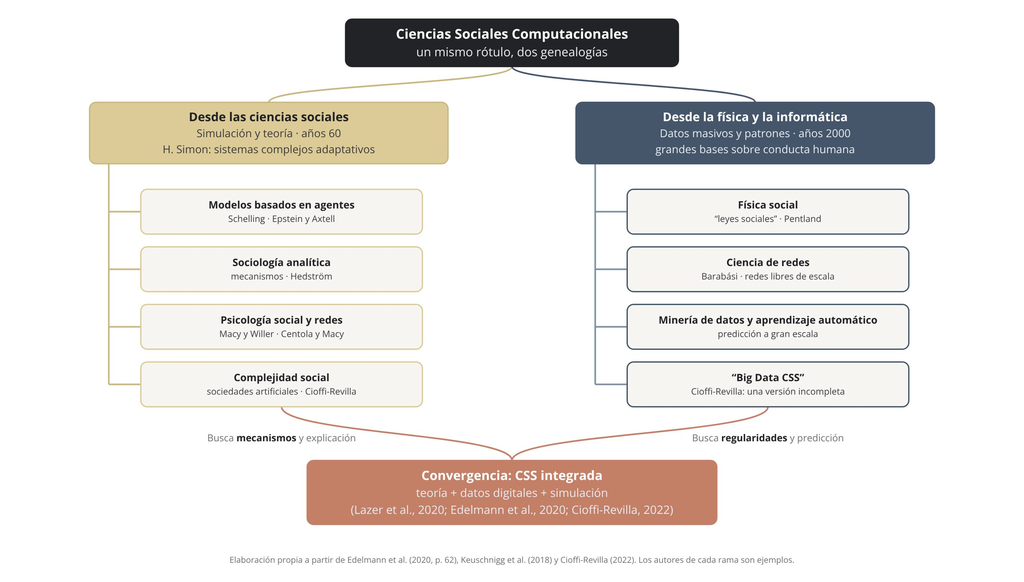

Seminario Doctoral · Ciencias Sociales ComputacionalesMódulo 1 · CSS

1.1 · Ciencias Sociales Computacionales

## ¿Qué tipo de ciencia es? Tres tesis

Tesis 1

### Ciencia empírica

Produce descripciones, explicaciones y, opcionalmente, predicciones sistemáticas, contrastables y reproducibles. **Las leyes describen; las teorías explican** (Toulmin).

**Ejemplos:** ley de Duverger, ley de Zipf, ley de Pareto. Describen un patrón, pero no dicen por qué ocurre.

Tesis 2

### Ciencia social

Como la astronomía computacional es astronomía, la CSS es parte de las **“cinco grandes”**: antropología, economía, ciencia política, psicología social y sociología. Toma de ellas sus mecanismos y les devuelve teorías.

**Implicancia:** sin teoría social, los resultados de la minería de datos son ininteligibles.

Tesis 3

### Ciencia computacional

La computación tiene una **naturaleza dual**: es instrumento (hardware, software, simulación de problemas de alta dimensionalidad) y es paradigma teórico (la sociedad como sistema de procesamiento de información).

**Implicancia:** la simulación es necesaria cuando no hay solución en forma cerrada.

Cioffi-Revilla (2022, pp. 19–22).

Seminario Doctoral · Ciencias Sociales ComputacionalesMódulo 1 · CSS

1.1 · Ciencias Sociales Computacionales

## El alcance del campo: núcleo, fronteras y zonas limítrofes

[figure not shown]

Fig. 1 — Alcance de la CSS según Cioffi-Revilla (2022, pp. 22–25). Elaboración propia.

Las áreas del núcleo están **ordenadas**: cada una puede enriquecerse con las anteriores, pero puede estudiarse sin las siguientes. El *big data* vive sobre todo en el área 2; no es todo el campo.

### Tres niveles de integración

- **Disciplinar:** sociología, economía o arqueología computacional.
- **Multidisciplinar:** se suman disciplinas sin buscar unificarlas.
- **Interdisciplinar:** integración por conceptos comunes (complejidad, redes, información).

**Los ciegos y el elefante.** Varios ciegos tocan un elefante: uno palpa los colmillos, otro las patas, otro las orejas. No logran ponerse de acuerdo, porque cada uno toma su parte por el animal completo; solo el dueño, que lo ve entero, lo entiende. Para Cioffi-Revilla (2022, p. 18), las definiciones estrechas de la CSS (“es *big data*”, “es redes”, “es simulación”) hacen lo mismo: describen una parte del campo y la confunden con el todo.

Seminario Doctoral · Ciencias Sociales ComputacionalesMódulo 1 · CSS

1.1 · Ciencias Sociales Computacionales

## ¿Qué cambia respecto de la ciencia social cuantitativa?

Ciencia social cuantitativa tradicional

### Filas de casos, columnas de variables

- Supuesto de **independencia** entre observaciones.
- Datos autorreportados de una sola vez: la encuesta como instantánea.
- Redes de “decenas de personas” observadas en un momento (Lazer et al., 2009).
- Coleman: una técnica para individuos independientes terminó dominando una disciplina dedicada a sistemas de individuos **interdependientes** (Keuschnigg et al., 2018, p. 6).

→

Ciencias sociales computacionales

### Lenguaje, ubicación, redes, imágenes

- Modelos estadísticos que capturan **dependencias múltiples** dentro de los datos (Lazer et al., 2020, p. 1060).
- Datos longitudinales, minuto a minuto, de poblaciones completas.
- Experimentos “macrosociológicos”: muchos mundos sociales paralelos como unidad de análisis.
- Herramientas que funcionarían como **“la econometría de la sociología”** (Keuschnigg et al., 2018).

Seminario Doctoral · Ciencias Sociales ComputacionalesMódulo 1 · CSS

1.2

## El papel de la teoría en la era del big data

Seminario Doctoral · Ciencias Sociales ComputacionalesMódulo 1 · Teoría

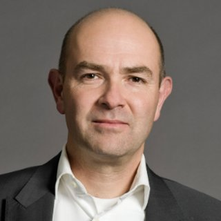

1.2 · El papel de la teoría en la era del big data

> “Con suficientes datos, los números hablan por sí mismos.”

Chris Anderson (2008), “The End of Theory”, *Wired*. Citado en Hollingshead et al. (2022, p. 172).

La tesis del “fin de la teoría” fue la provocación fundacional del *big data*. Las lecturas la rechazan desde tres lugares: **Cioffi-Revilla** (sin teoría los algoritmos son ininteligibles), **Edelmann et al.** (el futuro del campo depende de su capacidad de producir teoría) y **González-Bailón** (los patrones agregados no revelan los mecanismos que los producen). Incluso la detección exploratoria de patrones depende de supuestos teóricos sobre cómo se recolectan e interpretan los datos (Geise y Waldherr, 2022).

Seminario Doctoral · Ciencias Sociales ComputacionalesMódulo 1 · Teoría

1.2 · El papel de la teoría en la era del big data

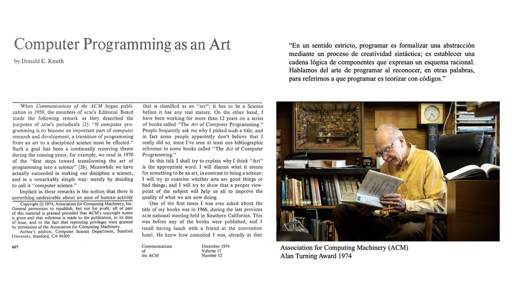

Seminario Doctoral · Ciencias Sociales ComputacionalesMódulo 1 · Teoría

1.2 · El papel de la teoría en la era del big data

## Describir, explicar, predecir

Describir

### Regularidades

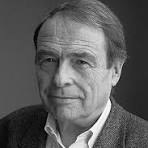

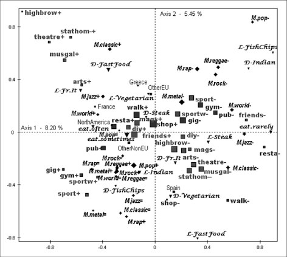

Medir y formalizar patrones. Bourdieu (*La distinción*, 1979) **describe** el espacio social de los gustos con análisis de correspondencias múltiples: quién se parece a quién.

**Límite:** “las leyes describen; las teorías explican” (Cioffi-Revilla, 2022, p. 20).

Explicar

### Mecanismos

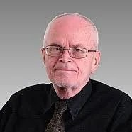

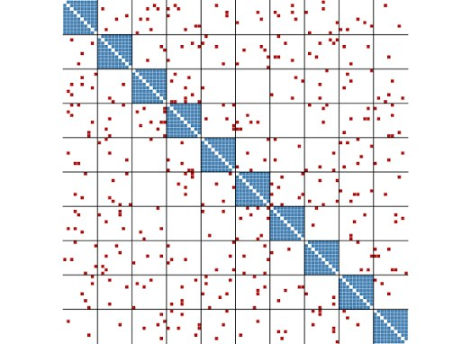

Identificar qué entidades e interacciones producen el fenómeno. White, Boorman y Breiger (1976) inventan el **modelamiento de bloques**: actores con los mismos vínculos ocupan el mismo rol.

**Ejemplo:** Bearman et al. explican una red romántica adolescente en forma de árbol con una norma contra ciclos de largo cuatro.

Predecir

### Simular para predecir

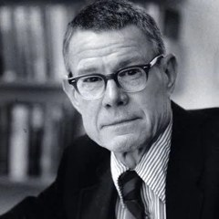

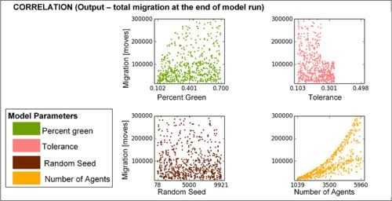

Los **modelos basados en agentes** programan reglas simples de conducta y simulan su interacción para anticipar el resultado agregado bajo distintos escenarios.

**Ejemplo:** en el modelo de Schelling (1971), una leve preferencia por vecinos similares basta para segregar. La figura muestra cómo la migración simulada cambia con la tolerancia y el número de agentes.

Seminario Doctoral · Ciencias Sociales ComputacionalesMódulo 1 · Teoría

1.2 · El papel de la teoría en la era del big data

## El problema micro–macro: por qué el agregado engaña

[figure not shown]

Fig. 2 — Esquema micro–macro (Coleman, 1990) aplicado al modelo de Schelling (1969). Elaboración propia.

Schelling mostró que personas **sin preferencias segregacionistas** pueden producir segregación extrema. El patrón macro dice poco sobre el mecanismo que lo generó (González-Bailón, 2017, p. 29; Keuschnigg et al., 2018, p. 5).

Para la sociología analítica, explicar un agregado exige (1) un modelo, posiblemente de simulación, que muestre cómo los individuos lo producen y (2) evidencia de que ese modelo es plausible en el caso.

Edelmann et al. (2020, p. 74): el trabajo más influyente de la CSS será el que **conecte teorías macro con procesos micro** de decisión, con métodos híbridos.

Seminario Doctoral · Ciencias Sociales ComputacionalesMódulo 1 · Teoría

1.2 · El papel de la teoría en la era del big data

## Viejos enigmas, nueva evidencia

[figure not shown]

**Robert K. Merton**  
(1910–2003)

Merton (1936)

### Consecuencias no intencionadas

**Idea:** lo que hacemos con un propósito produce efectos que nadie buscó.

**Por qué:** actuamos con información incompleta y cometemos errores en un mundo social complejo.

**Ejemplo:** la Web, creada para compartir ciencia, terminó alimentando el negocio de Google (pp. 26–28).

Merton (1948)

### Profecía autocumplida

**Idea:** una creencia falsa se vuelve verdadera porque la gente actúa como si fuera cierta.

**Por qué:** la conducta de unos refuerza la de otros (**retroalimentación positiva**).

**Ejemplo:** corre el rumor de que un banco quebrará, todos retiran su dinero y el banco quiebra (pp. 31–34).

Merton (1968)

### Efecto Mateo

**Idea:** al que tiene, se le dará más: las ventajas iniciales se acumulan.

**Por qué:** los nuevos vínculos prefieren a quien ya tiene muchos (**apego preferencial**).

**Ejemplo:** las citas científicas, los sitios web más enlazados y los contenidos virales (pp. 35–41).

Seminario Doctoral · Ciencias Sociales ComputacionalesMódulo 1 · Teoría

1.2 · El papel de la teoría en la era del big data

## Simular un mecanismo: el apego preferencial

**El mecanismo:** cada sitio web nuevo se enlaza con mayor probabilidad a los sitios que **ya tienen más vínculos**. Así, una pequeña ventaja obtenida por azar se convierte en una **gran desigualdad**.

[figure not shown]

**t₁ · Igualdad.** Tres sitios, cada uno con **2 vínculos**. Nadie tiene ventaja.

**t₂ · Azar.** Dos sitios nuevos se enlazan al **terracota**, que pasa a tener **4 vínculos**.

**t₃ · Ventaja acumulada.** Los nuevos prefieren al más conectado: el terracota llega a **8**; el blanco se queda en 3.

**t₄ · Desigualdad.** El terracota tiene **13**, el blanco sigue con 3 y casi todos los demás tienen **solo 1**.

Fig. 3 — Simulación propia inspirada en González-Bailón (2017, fig. 2.1). **Barras:** cuántos sitios tienen cada número de vínculos.

Seminario Doctoral · Ciencias Sociales ComputacionalesMódulo 1 · Teoría

1.2 · El papel de la teoría en la era del big data

## Omnívoro cultural *vs.* snob: el gusto medido con Spotify

[figure not shown]

Fig. 4 — Cada punto es un usuario. Datos simulados con fines ilustrativos.

**Snob (Bourdieu, 1979):** las clases altas se distinguen por consumir **solo cultura “legítima”**: música clásica, jazz, ópera.

**Omnívoro (Peterson y Kern, 1996):** hoy se distinguen por la **amplitud**: escuchan clásica, pero también cumbia o reggaetón.

**Con big data:** los registros de escucha de Spotify muestran qué géneros escucha cada usuario y cuánto, para **millones de perfiles y sin encuesta**. La diversidad se mide con la entropía *H* (eje horizontal). Anderson et al. (2020) usan estos datos para distinguir usuarios **generalistas** y **especialistas**.

**Límite:** Spotify no registra la clase social. Para contrastar la teoría hay que vincular los perfiles con encuestas o **indicadores indirectos** (comuna, tipo de plan).

Seminario Doctoral · Ciencias Sociales ComputacionalesMódulo 1 · Teoría

1.2 · El papel de la teoría en la era del big data

## Tres vías para construir teoría con CSS

Vía 1

### Volver a viejas preguntas

Nuevos datos y métodos permiten estudiar preguntas que se creían imposibles: teorías macro de redes y cambio cultural, teorías micro de toma de decisiones.

Vía 2

### Teorizar la *terra incognita* digital

Los nuevos espacios sociales avanzan más rápido que la teoría sociológica. Faltan teorías de la protesta digital, del consumo cultural en línea y de la interacción entre máquinas.

Vía 3

### Nuevas formas de hacer teoría

El aprendizaje automático no permitirá “hacer ingeniería inversa” de la cultura, pero la **brecha entre predicción y realidad** sirve para descubrir dimensiones ignoradas y puntos ciegos.

Seminario Doctoral · Ciencias Sociales ComputacionalesMódulo 1 · Teoría

1.3

## Datos en la era del big data

Seminario Doctoral · Ciencias Sociales ComputacionalesMódulo 1 · Datos

1.3 · Datos en la era del big data

## Datos encontrados y datos diseñados

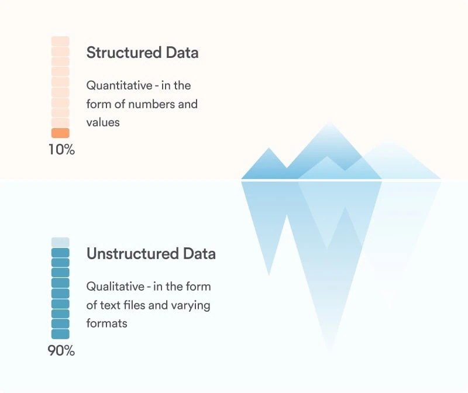

**La punta del iceberg.** Los datos **estructurados** (números en tablas) son una fracción menor; la mayor parte de los datos digitales son **no estructurados**: texto, imágenes, audio. El 90% es una estimación habitual en la industria, no una medición precisa.

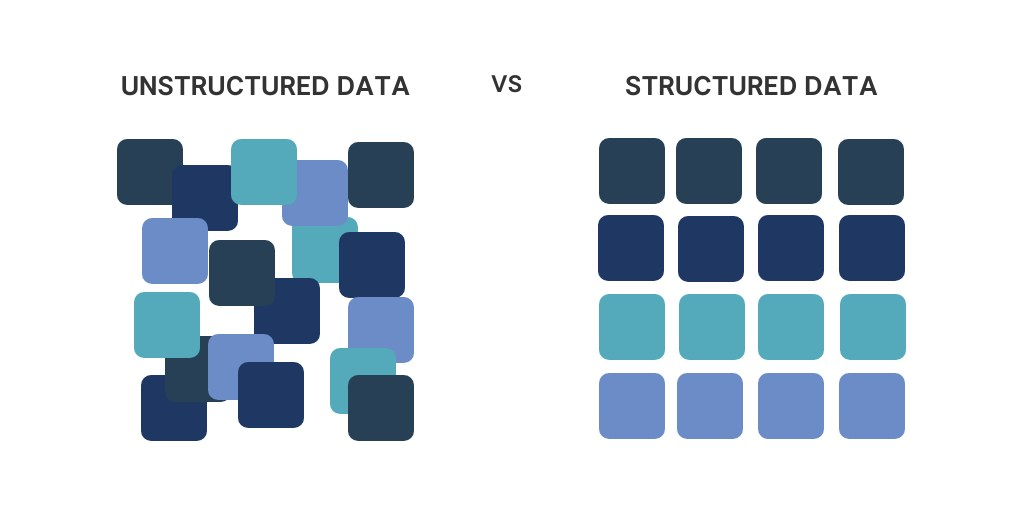

**Ordenar antes de analizar.** Los datos **diseñados** (encuestas, experimentos) nacen ordenados en filas y columnas. Los datos **encontrados** suelen llegar desordenados: hay que codificarlos y clasificarlos para volverlos variables.

Seminario Doctoral · Ciencias Sociales ComputacionalesMódulo 1 · Datos

1.3 · Datos en la era del big data

## Datos encontrados y datos diseñados

[figure not shown]

Duchamp · *readymade*

### Datos encontrados

Registros creados por empresas y gobiernos para otros fines, que el investigador **reutiliza**: llamadas telefónicas, cajas de supermercado, búsquedas, publicaciones en plataformas.

Ejemplos de formatos

- Documentación histórica
- Archivos administrativos
- Registros de prensa
- Imágenes
- Grabaciones

+

[figure not shown]

Miguel Ángel · *custommade*

### Datos diseñados

Datos producidos para la pregunta: encuestas, experimentos en línea, colaboración masiva. Más caros, pero con control sobre medición, muestra y asignación.

Ejemplos de formatos

- Encuestas
- Cuestionarios
- Bases de datos
- Entrevistas
- Grupos focales

Seminario Doctoral · Ciencias Sociales ComputacionalesMódulo 1 · Datos

1.3 · Datos en la era del big data

## Diez características de las fuentes de *big data*

Casi todas surgen porque estos datos **no fueron creados para investigar**. Salganik las divide en tres útiles y siete problemáticas.

#### Generalmente útiles

**Grandes**Millones de casos: permiten estudiar **grupos pequeños y eventos raros**. *Ej.: Chetty et al. miden movilidad social barrio por barrio con 40 millones de declaraciones de impuestos.*

**Siempre encendidos**Se registran **todo el tiempo**, no solo cuando alguien pregunta: sirven para eventos inesperados. *Ej.: tuits publicados antes, durante y después de las protestas del parque Gezi (Turquía, 2013).*

**No reactivos**Las personas **no saben que están siendo medidas**, así que no ajustan su respuesta. *Ej.: búsquedas en Google sobre temas que nadie admitiría en una encuesta.*

#### Generalmente problemáticas

**Incompletos**Rara vez traen las **variables que necesitamos**: edad, ingreso, opiniones. *Ej.: un registro de llamadas dice con quién hablas, pero no si eres pobre.*

**Inaccesibles**Los tienen **empresas o gobiernos**, que no los comparten. *Ej.: los datos de un banco, de Uber o de Meta.*

**No representativos**Los usuarios de una plataforma **no son la población**. *Ej.: en Chile, X (Twitter) tiende a sobrerrepresentar a personas jóvenes, urbanas y politizadas.*

**A la deriva**La plataforma, sus usuarios y lo que registra **cambian con el tiempo**. *Ej.: en 2017 Twitter pasó de 140 a 280 caracteres: los tuits se alargan sin que cambie la gente.*

**Confundidos algorítmicamente**Lo observado es en parte **producto del diseño** de la plataforma. *Ej.: Facebook sugiere “personas que quizás conozcas”, lo que infla los amigos en común.*

**Sucios****Bots, spam y errores** que parecen conducta humana. *Ej.: un mensaje automático repetido miles de veces hizo creer que la ira aumentó tras el 11-S.*

**Sensibles**Revelan **información íntima** aunque no tengan nombres. *Ej.: con las calificaciones “anónimas” de Netflix se logró reidentificar a usuarios (Narayanan y Shmatikov, 2008).*

Salganik (2018, sección 2.3); la mayoría de los ejemplos vienen del mismo capítulo; los de Chile y Twitter son propios. Traducción y síntesis propias.

Seminario Doctoral · Ciencias Sociales ComputacionalesMódulo 1 · Datos

1.3 · Datos en la era del big data

## Más datos no reemplazan un buen diseño

Meng (2018) estudió la intención de voto por Trump en 2016 con datos del *Cooperative Congressional Election Study*: una **muestra aleatoria de 400 casos** entrega el mismo error de estimación que una **muestra no aleatoria de 2,3 millones**.

El sesgo de selección no disminuye con el tamaño: se multiplica por él. En plataformas, quienes no usan internet o no tienen cuenta quedan excluidos por diseño (Hollingshead et al., 2022).

La pregunta doctoral no es “¿cuántos datos?” sino **“¿quién falta, por qué, y qué le hace eso a mi inferencia?”** Ver también el marco de error total para trazas digitales (Sen et al., 2022, Vol. II).

Seminario Doctoral · Ciencias Sociales ComputacionalesMódulo 1 · Datos

1.3 · Datos en la era del big data

## ¿Quién tiene los datos?

Lazer et al. (2020) consideran “inaceptable” que la CSS dependa de acuerdos *ad hoc* con empresas. Proponen pasar de un sistema voluntario e inestable a infraestructuras públicas, seguras y auditables.

[figure not shown]

Fig. 6 — Síntesis de Lazer et al. (2020, pp. 1060–1062). Ejemplos citados: ODISSEI (Países Bajos), Secure Data Center de GESIS, Social Science One.

Seminario Doctoral · Ciencias Sociales ComputacionalesMódulo 1 · Datos

1.4

## La cuestión ética en el diseño

Seminario Doctoral · Ciencias Sociales ComputacionalesMódulo 1 · Ética

1.4 · La cuestión ética en el diseño

## La ética, de la advertencia a la deuda pendiente

Lazer et al. (2009) · advertencia

### Privacidad y reidentificación

- Los registros “anonimizados” de búsqueda de AOL permitieron identificar a sus usuarios.
- Bases genéticas agregadas fueron retiradas tras demostrarse que era posible desanonimizar.
- Un solo incidente dramático podría producir reglas que **asfixien** el campo naciente.
- Propuesta: un régimen de **autorregulación** y comités de ética con conocimiento técnico.

→

Lazer et al. (2020) · balance

### “Reglas del camino” que no llegaron

- Pese a fallas graves, el campo no articuló principios claros para datos digitales sobre personas.
- Cambridge Analytica abrió un debate sobre **soberanía de datos** polarizado entre empresas y defensores de la privacidad.
- **Consentimiento en red:** compartir información sobre uno mismo revela información de sus vínculos.
- La CSS debe abrir la caja negra de algoritmos que toman decisiones y pueden incorporar sesgos (Obermeyer et al., 2019).

Seminario Doctoral · Ciencias Sociales ComputacionalesMódulo 1 · Ética

1.4 · La cuestión ética en el diseño

## Cuatro principios para decidir sin reglas claras

Salganik (2018) propone razonar desde principios, porque en la era digital **lo posible avanza más rápido que lo normado**. Hollingshead et al. (2022) agregan cuatro desafíos de diseño: representatividad, agregación, archivo de datos y vinculación de bases.

01

### Respeto por las personas

Tratar a las personas como autónomas y proteger a quienes tienen autonomía disminuida.

Pregunta de diseño: ¿quién consintió y a qué?

02

### Beneficencia

Entender y mejorar el balance de riesgos y beneficios: no dañar y maximizar beneficios.

Pregunta de diseño: ¿qué daño es posible si los datos se filtran o se cruzan?

03

### Justicia

Distribuir con equidad los riesgos y los beneficios de la investigación.

Pregunta de diseño: ¿quién carga los costos y quién se queda con los resultados?

04

### Respeto por la ley y el interés público

Extiende la beneficencia más allá de los participantes: cumplimiento y transparencia.

Pregunta de diseño: ¿violo términos de servicio? ¿lo haría público?

Seminario Doctoral · Ciencias Sociales ComputacionalesMódulo 1 · Ética

1.4 · La cuestión ética en el diseño

## El sesgo algorítmico como profecía autocumplida

**Vigilancia predictiva:** clasificar a un grupo como potencialmente desviado moldea su conducta en la dirección confirmatoria, como mostró la sociología del estigma (Becker, Goffman).

**Discriminación por inferencia estadística:** búsquedas de nombres asignados mayoritariamente a bebés negros mostraban más avisos que sugerían antecedentes de arresto.

**Salud:** Lazer et al. (2020) citan un algoritmo de salud con sesgo racial (Obermeyer et al., 2019).

Para González-Bailón, romper el ciclo es **una decisión social y no técnica**; los datos digitales sirven tanto para perfilar como para documentar la discriminación.

Seminario Doctoral · Ciencias Sociales ComputacionalesMódulo 1 · Ética

02

## Discusión sobre lecturas

Del manifiesto a la práctica: qué estudia hoy el campo, qué exige saber programar y qué preguntas abre.

2.1 · Áreas de investigación2.2 · Programación2.3 · Potencial analítico

Seminario Doctoral · Ciencias Sociales ComputacionalesMódulo 2

2.1

## Áreas de investigación

Seminario Doctoral · Ciencias Sociales ComputacionalesMódulo 2 · Áreas

2.1 · Áreas de investigación

## Siete subcampos de la CSS en sociología

Edelmann et al. mapean el campo con sus propias herramientas: red de citas, detección de comunidades (Louvain, 24 áreas) y codificación manual de **248 artículos sociológicos**. Incluyen subcampos con al menos cinco estudios.

| Subcampo | Pregunta y hallazgo representativos | Datos y métodos |
| --- | --- | --- |
| Redes y formación de grupos | Las difusiones llegan más lejos en redes con mucho agrupamiento (Centola, 2010); vínculos de largo alcance pueden ser fuertes (Park et al., 2018). | Experimentos en línea, telecomunicaciones |
| Acción colectiva y política | Exponerse a opiniones opuestas en Twitter puede aumentar la polarización (Bail et al., 2018). | Experimento de campo con bots |
| Sociología del conocimiento | Los equipos pequeños producen ideas más disruptivas que los grandes (Wu et al., 2019). | Redes de citas, texto |
| Cultura, psicología social y emociones | Los *embeddings* trazan cambios de significado de clase y género (Kozlowski et al., 2019). | Texto, realidad virtual |
| Producción cultural | La influencia social vuelve impredecible el éxito musical (Salganik et al., 2006). | Mercados artificiales, Spotify |
| Sociología económica y organizaciones | Quienes encajan en la cultura organizacional reciben recompensas (Goldberg et al., 2016). | Correos y mensajería interna |
| Demografía y población | Estimar migración con Twitter y LinkedIn; el *Fragile Families Challenge* (Salganik et al., 2020). | Telefonía, anuncios, competencias |

Seminario Doctoral · Ciencias Sociales ComputacionalesMódulo 2 · Áreas

2.1 · Áreas de investigación

## Para discutir: lo que el mapa no muestra

Ausencias en la sociología

### Subcampos donde la CSS casi no ha entrado

- Raza y etnicidad
- Criminología
- Educación
- Desigualdad y estratificación
- Religión
- Sexo y género
- Derecho
- Sociología médica
- Sociología histórica

Edelmann et al. (2020, p. 75).

Hipótesis de los autores: la primera ola de datos digitales favoreció ciertas preguntas. La digitalización de archivos históricos, clínicos y policiales abre las demás (Brayne, 2020).

↔

Contrapunto · Cioffi-Revilla (2022)

### Un núcleo más amplio que la sociología

El mapa de Edelmann es disciplinar. Cioffi-Revilla ubica en el núcleo la **complejidad social** (12.000 años de evolución de sociedades) y las **simulaciones**, y propone las crisis complejas (pandemias, cambio climático) como objeto ejemplar.

Para un doctorado en Chile: ¿qué archivos administrativos, judiciales o culturales locales permitirían entrar a los subcampos vacíos?

Seminario Doctoral · Ciencias Sociales ComputacionalesMódulo 2 · Áreas

2.2

## El papel de la programación en la investigación social

Seminario Doctoral · Ciencias Sociales ComputacionalesMódulo 2 · Programación

2.2 · El papel de la programación en la investigación social

## Programar es formalizar un mecanismo

### Instrumento y paradigma

Para Cioffi-Revilla la computación es a la vez **herramienta** y **teoría**. Sus fundamentos (abstracción, estructuras de datos, algoritmos) son el área 1 del núcleo, porque obligan a explicitar entidades, reglas e interacciones.

### Una brecha de formación

Lazer et al. (2009) preguntaban si formar científicos sociales computacionales o equipos de **científicos sociales con alfabetización computacional** y científicos de la computación con alfabetización social. En 2020 constatan que enseñar a programar a científicos sociales “ha sido lento” y que la formación sigue en silos.

Respuesta parcial: las *Summer Institutes in Computational Social Science* (Edelmann et al., 2020, p. 75).

#### El mecanismo de la Fig. 3, en siete líneas de Python

```
import random

grado = [2, 2, 2]             # t1: tres sitios idénticos
for t in range(1000):         # llegan sitios nuevos
    i = random.choices(range(len(grado)),
                       weights=grado)[0]
    grado[i] += 1             # enlaza con prob. ∝ grado
    grado.append(1)           # el sitio nuevo entra con 1
```

Cada línea es un supuesto teórico discutible: ¿por qué proporcional al grado y no a la similitud (Papadopoulos et al., 2012)? ¿Por qué un solo vínculo? Escribir el código vuelve visibles esas decisiones.

**Flujo de trabajo:** recolección (APIs, *scraping*) → limpieza y vinculación → análisis → reproducibilidad (Handbook, Vol. II, caps. 2–8).

Seminario Doctoral · Ciencias Sociales ComputacionalesMódulo 2 · Programación

2.3

## Potencial analítico

Seminario Doctoral · Ciencias Sociales ComputacionalesMódulo 2 · Potencial analítico

2.3 · Potencial analítico

## Qué preguntas se vuelven posibles

Cruzando los cuatro modos de investigación de Salganik (2018) con los ejemplos de las lecturas: el potencial de la CSS está menos en el tamaño de los datos que en **observar procesos, intervenir sistemas y simular contrafactuales**.

Observar conducta

### Trazas en el tiempo

Datos siempre encendidos para seguir difusión, movilidad y comunicación.

Ritmos diarios de las emociones en Twitter (Golder y Macy, 2011).

Riesgo: confusión algorítmica y deriva.

Hacer preguntas

### Encuestas ampliadas

Combinar encuestas con trazas para imputar y escalar: pobreza a partir de llamadas, muestras no probabilísticas ajustadas.

Riesgo: no representatividad (Meng, 2018).

Experimentar

### Macroexperimentos

Muchos mundos sociales paralelos como unidad de análisis (*Music Lab*); experimentos de campo en plataformas.

Riesgo: ética de la intervención (Emotional Contagion).

Simular y colaborar

### Contrafactuales

Modelos basados en agentes calibrados empíricamente como **“simulador de vuelo social”** (Keuschnigg et al., 2018); colaboración masiva y desafíos predictivos.

Riesgo: validación del modelo.

Seminario Doctoral · Ciencias Sociales ComputacionalesMódulo 2 · Potencial analítico

2.3 · Potencial analítico

> El *Fragile Families Challenge* no produjo avances importantes sobre los modelos existentes, pero ofreció una “prueba de fuego” para el aprendizaje automático en la ciencia social.

Edelmann et al. (2020, p. 73), sobre Salganik et al. (2020). Paráfrasis y traducción propias.

**¿Qué fue?** Una competencia de colaboración masiva (Salganik et al., 2020) en la que **160 equipos** recibieron los datos del estudio *Fragile Families*: unas 4.000 familias de ciudades de EE. UU., seguidas desde el nacimiento de sus hijos hasta los 9 años, con **miles de variables**. Debían **predecir seis resultados a los 15 años**, como el rendimiento escolar, el desalojo del hogar o la pérdida de empleo de un cuidador. Incluso los mejores modelos de aprendizaje automático **apenas superaron a una regresión simple** con cuatro variables.

**Lectura:** es un límite al optimismo predictivo, pero también una oportunidad teórica: **la brecha entre predicción y realidad señala lo que nuestras teorías no ven**.

Seminario Doctoral · Ciencias Sociales ComputacionalesMódulo 2 · Potencial analítico

Discusión

## Preguntas para el seminario

Lazer et al. 2009 ↔ 2020

En 2009 se temía que la CSS quedara en manos de empresas. ¿Qué cambió en once años? ¿Fue la autorregulación un éxito o un fracaso?

González-Bailón 2017

Si los patrones agregados no revelan mecanismos, ¿qué agrega el *big data* a Merton y Schelling que no tuvieran ya los modelos formales?

Edelmann et al. 2020

¿Debe la CSS sociológica limitarse a estudios que explican? ¿Qué se pierde al excluir la predicción orientada a soluciones?

Cioffi-Revilla 2022

¿Es justa la crítica a una “Big Data CSS”? ¿Describe Cioffi-Revilla un campo existente o uno deseable?

Transversal · ética

Si el sesgo algorítmico es una profecía autocumplida, ¿dónde debe intervenir el investigador: en los datos, en el modelo o en la institución que decide?

Transversal · LLM

¿Son los LLM un nuevo instrumento de medición o un nuevo objeto de estudio? ¿Qué implica cada respuesta para la validez?

Seminario Doctoral · Ciencias Sociales ComputacionalesMódulo 2 · Discusión

Síntesis

## Cinco tensiones que estructuran el campo

Datos

Teoría

Lazer et al. (2009) parten de los datos; Cioffi-Revilla y Edelmann et al. exigen teoría.

Predecir

Explicar

Ciencia orientada a soluciones frente a explicación por mecanismos (Keuschnigg et al., 2018).

Escala

Representatividad

Millones de casos no corrigen el sesgo de selección (Meng, 2018; Salganik, 2018).

Acceso

Privacidad

Abrir los datos privados al interés público sin exponer a las personas (Lazer et al., 2020).

Infraestructura privada

Infraestructura abierta

De las APIs de plataformas a los LLM propietarios (Bail, 2024).

Seminario Doctoral · Ciencias Sociales ComputacionalesSíntesis

Referencias

## Bibliografía

#### Lecturas obligatorias

Cioffi-Revilla, C. (2022). The scope of computational social science. En U. Engel, A. Quan-Haase, S. X. Liu y L. Lyberg (Eds.), *Handbook of Computational Social Science, Vol. 1* (pp. 17–32). Routledge.

Edelmann, A., Wolff, T., Montagne, D. y Bail, C. A. (2020). Computational social science and sociology. *Annual Review of Sociology*, 46, 61–81. https://doi.org/10.1146/annurev-soc-121919-054621

González-Bailón, S. (2017). *Decoding the Social World: Data Science and the Unintended Consequences of Communication*, cap. 2: Old puzzles, new evidence (pp. 23–44). MIT Press.

Lazer, D., Pentland, A., Adamic, L., Aral, S., Barabási, A.-L., Brewer, D., et al. (2009). Computational social science. *Science*, 323(5915), 721–723.

Lazer, D. M. J., Pentland, A., Watts, D. J., Aral, S., Athey, S., Contractor, N., et al. (2020). Computational social science: Obstacles and opportunities. *Science*, 369(6507), 1060–1062.

#### Lecturas complementarias

Bail, C. A. (2024). Can generative AI improve social science? *PNAS*, 121(21), e2314021121.

Engel, U., Quan-Haase, A., Liu, S. X. y Lyberg, L. (Eds.). (2022). *Handbook of Computational Social Science* (Vols. 1–2). Routledge.

Geise, S. y Waldherr, A. (2022). Computational communication science. En Engel et al. (Eds.), *Handbook…, Vol. 1* (pp. 66–82).

Hollingshead, W., Quan-Haase, A. y Chen, W. (2022). Ethics and privacy in computational social science. En Engel et al. (Eds.), *Handbook…, Vol. 1* (pp. 171–185).

Keuschnigg, M., Lovsjö, N. y Hedström, P. (2018). Analytical sociology and computational social science. *Journal of Computational Social Science*, 1, 3–14.

Salganik, M. J. (2018). *Bit by Bit: Social Research in the Digital Age*. Princeton University Press.

Ziems, C., Held, W., Shaikh, O., Chen, J., Zhang, Z. y Yang, D. (2024). Can large language models transform computational social science? *Computational Linguistics*, 50(1), 237–291.

Seminario Doctoral · Ciencias Sociales ComputacionalesReferencias

Cierre

# Muchas gracias.

Roberto Velázquez-Quiroz  
Seminario Doctoral · Ciencias Sociales Computacionales  
github.com/rovelazqu

Seminario Doctoral · Ciencias Sociales ComputacionalesSesión 1